# IPython

**IPython** is an enhanced Python shell which provides a more robust and productive development environment for users. There are several key features that set it apart from the standard Python shell .

### History

In IPython, all your inputs and outputs are saved. There are two variables named `In` and `Out` which are assigned as you work with your results. All outputs are saved automatically to variables of the form `_N`, where `N` is the prompt number, and inputs to `_iN`. This allows you to recover quickly the result of a prior computation by referring to its number even if you forgot to store it as a variable.

```python
import numpy as np
np.sin(4)**2
```

```
0.57275001690430671
```

```python
_1
```

```
0.57275001690430671
```

```python
_i1
```

```
u'import numpy as np\nnp.sin(4)**2'
```

```python
_1 / 4.
```

```
0.14318750422607668
```

### Introspection

If you want details regarding the properties and functionality of any Python objects currently loaded into IPython, you can use the `?` to reveal any details that are available:

```python
some_dict = {}
some_dict?
```

If available, additional detail is provided with two question marks, including the source code of the object itself.

```python
from numpy.linalg import cholesky
cholesky??
```

This syntax can also be used to search namespaces with wildcards (*).

```python
import pylab as plt
plt.*plot*?
```

### Tab completion

Because IPython allows for introspection, it is able to afford the user the ability to tab-complete commands that have been partially typed. This is done by pressing the `<tab>` key at any point during the process of typing a command:

```python
np.
```

This can even be used to help with specifying arguments to functions, which can sometimes be difficult to remember:

```python
plt.hist(
```

### System commands

In IPython, you can type `ls` to see your files or `cd` to change directories, just like you would at a regular system prompt:

```python
pwd
```

```
u'/Users/fonnescj/Bios366/notebooks'
```

```python
ls ../*.py
```

```
../generate_data.py  ../svm_digits.py     ../test_tutorial.py
```

Virtually any system command can be accessed by prepending `!`, which passes any subsequent command directly to the OS.

```python
!mdfind -onlyin /Users/jfsantos/Dropbox "ipynb" | grep SummerWorkshop
```

```
/Users/jfsantos/Dropbox/INRS/Summer 2014/MuSAELabSummerWorkshop/Python/Section2_1-IPython.ipynb
/Users/jfsantos/Dropbox/INRS/Summer 2014/MuSAELabSummerWorkshop/Python/Section2_2-NumPy.ipynb
/Users/jfsantos/Dropbox/INRS/Summer 2014/MuSAELabSummerWorkshop/Python/Section1_1-Introduction-to-Python.ipynb
/Users/jfsantos/Dropbox/INRS/Summer 2014/MuSAELabSummerWorkshop/Python/Section1_2-Programming-with-Python.ipynb
/Users/jfsantos/Dropbox/INRS/Summer 2014/MuSAELabSummerWorkshop/Python/Section2_3-SciPy.ipynb
/Users/jfsantos/Dropbox/INRS/Summer 2014/MuSAELabSummerWorkshop/Python/Section2_4-Matplotlib.ipynb
/Users/jfsantos/Dropbox/INRS/Summer 2014/MuSAELabSummerWorkshop/Python/Section2_5-Introduction-to-Pandas.ipynb
/Users/jfsantos/Dropbox/INRS/Summer 2014/MuSAELabSummerWorkshop/Python/Section2_6-Data-Wrangling-with-Pandas.ipynb
/Users/jfsantos/Dropbox/INRS/Summer 2014/MuSAELabSummerWorkshop/Python/Section2_7-Plotting-with-Pandas.ipynb
/Users/jfsantos/Dropbox/INRS/Summer 2014/MuSAELabSummerWorkshop/Python/Section6_1-Scikit-Learn.ipynb
/Users/jfsantos/Dropbox/INRS/Summer 2014/MuSAELabSummerWorkshop/Python/Section6_2-Clustering.ipynb
/Users/jfsantos/Dropbox/INRS/Summer 2014/MuSAELabSummerWorkshop/Python/Section6_3-Model-Selection-and-Validation.ipynb
/Users/jfsantos/Dropbox/INRS/Summer 2014/MuSAELabSummerWorkshop/Python/Section6_4-Support-Vector-Machines.ipynb
/Users/jfsantos/Dropbox/INRS/Summer 2014/MuSAELabSummerWorkshop/Python/Section6_5-Decision-Trees.ipynb
/Users/jfsantos/Dropbox/INRS/Summer 2014/MuSAELabSummerWorkshop/Best practices - examples.ipynb
/Users/jfsantos/Dropbox/INRS/Summer 2014/MuSAELabSummerWorkshop/Best Practices for Scientific Computing.ipynb
```

You can even use Python variables in commands sent to the OS:

```python
file_type = 'jpg'
!ls ../*$file_type
```

```
../musae.jpg
```

The output of a system command using the exclamation point syntax can be assigned to a Python variable.

```python
pkl_files = !ls ../*.pkl
```

```python
pkl_files
```

```
['../digits.pkl', '../results_hyperopt.pkl']
```

## Qt Console

If you type at the system prompt:

```
$ ipython qtconsole
```

instead of opening in a terminal, IPython will start a graphical console that at first sight appears just like a terminal, but which is in fact much more capable than a text-only terminal. This is a specialized terminal designed for interactive scientific work, and it supports full multi-line editing with color highlighting and graphical calltips for functions, it can keep multiple IPython sessions open simultaneously in tabs, and when scripts run it can display the figures inline directly in the work area.

[figure not shown]

# iPython Notebook

IPython includes the *HTML notebook* featured here, as well as support for **interactive data visualization** and easy high-performance **parallel computing**.

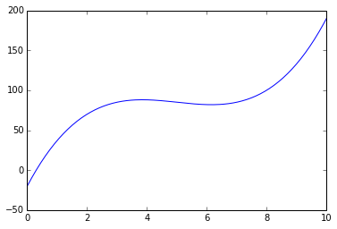

```python
def f(x):
    return (x-3)*(x-5)*(x-7)+85

import numpy as np
x = np.linspace(0, 10, 200)
y = f(x)
plot(x,y)
```

The notebook lets you document your workflow using either HTML or Markdown.

The IPython Notebook consists of two related components:

- A JSON based Notebook document format for recording and distributing Python code and rich text.
- A web-based user interface for authoring and running notebook documents.

The Notebook can be used by starting the Notebook server with the command:

```
$ ipython notebook
```

This initiates an **iPython engine**, which is a Python instance that takes Python commands over a network connection. If we want to enable inline plotting of figures via Matplotlib, we can add a `--pylab inline` flag to the command.

The **IPython controller** provides an interface for working with a set of engines, to which one or more **iPython clients** can connect.

The Notebook gives you everything that a browser gives you. For example, you can embed images, videos, or entire websites.

[figure not shown]

```python
from IPython.display import Image
Image("../musae.jpg")
```

```python
from IPython.display import HTML
HTML("<iframe src=http://musaelab.ca width=700 height=350></iframe>")
```

[interactive chart not shown]

```python
from IPython.display import YouTubeVideo
YouTubeVideo("QTk688cXTsA")
```

[video not shown]

### Remote Code

Use `%load` to add remote code

```python
%load http://matplotlib.org/mpl_examples/shapes_and_collections/scatter_demo.py
```

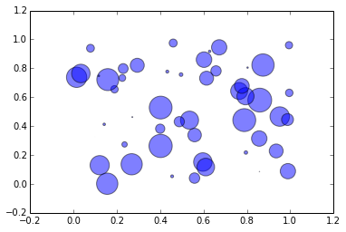

```python
"""
Simple demo of a scatter plot.
"""
import numpy as np
import matplotlib.pyplot as plt


N = 50
x = np.random.rand(N)
y = np.random.rand(N)
area = np.pi * (15 * np.random.rand(N))**2 # 0 to 15 point radiuses

plt.scatter(x, y, s=area, alpha=0.5)
plt.show()
```

### Mathjax Support

Mathjax ia a javascript implementation of LaTeX that allows equations to be embedded into HTML. For example, this markup:

```
"""$$ \int_{a}^{b} f(x)\, dx \approx \frac{1}{2} \sum_{k=1}^{N} \left( x_{k} - x_{k-1} \right) \left( f(x_{k}) + f(x_{k-1}) \right). $$"""
```

becomes this:

$$ \int_{a}^{b} f(x)\, dx \approx \frac{1}{2} \sum_{k=1}^{N} \left( x_{k} - x_{k-1} \right) \left( f(x_{k}) + f(x_{k-1}) \right). $$

## SymPy Support

SymPy is a Python library for symbolic mathematics. It supports:

- polynomials
- calculus
- solving equations
- discrete math
- matrices

```python
from sympy import *
%load_ext sympyprinting
x, y = symbols("x y")
```

```python
eq = ((x+y)**2 * (x+1))
eq
```

```python
expand(eq)
```

```python
(1/cos(x)).series(x, 0, 6)
```

```python
limit((sin(x)-x)/x**3, x, 0)
```

```python
diff(cos(x**2)**2 / (1+x), x)
```

### Magic functions

IPython has a set of predefined ‘magic functions’ that you can call with a command line style syntax. These include:

- `%run`
- `%edit`
- `%debug`
- `%timeit`
- `%paste`
- `%load_ext`

```python
%lsmagic
```

```
Available line magics:
%alias  %alias_magic  %autocall  %automagic  %autosave  %bookmark  %cd  %clear  %colors  %config  %connect_info  %debug  %dhist  %dirs  %doctest_mode  %ed  %edit  %env  %gui  %hist  %history  %install_default_config  %install_ext  %install_profiles  %killbgscripts  %less  %load  %load_ext  %loadpy  …

Available cell magics:
%%!  %%HTML  %%SVG  %%bash  %%capture  %%debug  %%file  %%html  %%javascript  %%latex  %%perl  %%prun  %%pypy  %%python  %%python3  %%ruby  %%script  %%sh  %%svg  %%sx  %%system  %%time  %%timeit  %%writefile

Automagic is ON, % prefix IS NOT needed for line magics.
```

Timing the execution of code; the `timeit` magic exists both in line and cell form:

```python
%timeit np.linalg.eigvals(np.random.rand(100,100))
```

```
100 loops, best of 3: 8.66 ms per loop
```

```python
%%timeit a = np.random.rand(100, 100)
np.linalg.eigvals(a)
```

```
100 loops, best of 3: 8.33 ms per loop
```

IPython also creates aliases for a few common interpreters, such as bash, ruby, perl, etc.

These are all equivalent to `%%script <name>`

```python
%%ruby
puts "Hello from Ruby #{RUBY_VERSION}"
```

```
Hello from Ruby 2.0.0
```

```python
%%bash
echo "hello from $BASH"
```

```
hello from /bin/bash
```

## MATLAB interface

There is an extension to IPython, [pymatbridge](https://github.com/arokem/python-matlab-bridge), that contains some magic functions for working with MATLAB. This extension can be loaded using the `%load_ext` magic as follows (as long as the MATLAB executable is in your path):

```python
%load_ext pymatbridge
```

```
Starting MATLAB on ZMQ socket ipc:///tmp/pymatbridge
Send 'exit' command to kill the server
..........MATLAB started and connected!
```

```python
# Or like this, if MATLAB is not in your path. Add it to your path!
import pymatbridge as pymat

ip = get_ipython()
pymat.load_ipython_extension(ip, matlab="/Applications/MATLAB_R2013a.app/bin/matlab")
```

```
Starting MATLAB on ZMQ socket ipc:///tmp/pymatbridge
Send 'exit' command to kill the server
............MATLAB started and connected!
```

```python
%%matlab
x = zeros(3)
```

```
x =

     0     0     0
     0     0     0
     0     0     0
```

```python
# We can pass Python variables to MATLAB and get back MATLAB variables as Python variables.
m = 3
n = 4
```

```python
%%matlab -i m,n -o X
X = rand(m,n)
```

```
X =

    0.8147    0.9134    0.2785    0.9649
    0.9058    0.6324    0.5469    0.1576
    0.1270    0.0975    0.9575    0.9706
```

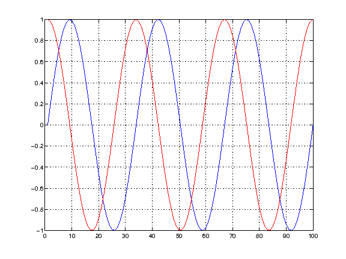

```python
%%matlab
t = linspace(0,6*pi,100);
plot(sin(t))
grid on
hold on
plot(cos(t), 'r')
```

```python
%matlab sombrero
```

[output not shown]

## Exporting and Converting Notebooks

In IPython, one can convert an `.ipynb` notebook document file into various static formats via the `nbconvert` tool. Currently, nbconvert is a command line tool, run as a script using IPython.

```python
%load Section2_1-IPython.tex
```

```python
!ipython nbconvert --to html Section2_1-IPython.ipynb
```

```
[NbConvertApp] Using existing profile dir: u'/Users/fonnescj/.ipython/profile_default'
[NbConvertApp] Converting notebook Section2_1-IPython.ipynb to html
[NbConvertApp] Support files will be in Section2_1-IPython_files/
[NbConvertApp] Loaded template html_full.tpl
[NbConvertApp] Writing 365978 bytes to Section2_1-IPython.html
```

Currently, `nbconvert` supports HTML (default), LaTeX, Markdown, reStructuredText, Python and HTML5 slides for presentations. Some types can be post-processed, such as LaTeX to PDF (this requires [Pandoc](http://johnmacfarlane.net/pandoc/) to be installed, however).

```python
!ipython nbconvert --to latex --post PDF Section1_2-Programming-with-Python.ipynb
```

```
[NbConvertApp] Using existing profile dir: u'/Users/fonnescj/.ipython/profile_default'
[NbConvertApp] Converting notebook Section1_2-Programming-with-Python.ipynb to latex
[NbConvertApp] Support files will be in Section1_2-Programming-with-Python_files/
[NbConvertApp] Loaded template latex_article.tplx
[NbConvertApp] Writing 107584 bytes to Section1_2-Programming-with-Python.tex
[NbConvertApp] Building PDF
[NbConvertApp] Running pdflatex 3 times: ['pdflatex', 'Section1_2-Programming-with-Python.tex']
[NbConvertApp] Running bibtex 1 time: ['bibtex', 'Section1_2-Programming-with-Python']
[NbConvertApp] WARNING | bibtex had problems, most likely because there were no citations
[NbConvertApp] Removing temporary LaTeX files
[NbConvertApp] PDF successfully created
```

A very useful online service is the [IPython Notebook Viewer](http://nbviewer.ipython.org) which allows you to display your notebook as a static HTML page, which is useful for sharing with others:

```python
from IPython.display import HTML
HTML("<iframe src=http://nbviewer.ipython.org/2352771 width=700 height=300></iframe>")
```

[interactive chart not shown]

## Reproducible Research

> reproducing conclusions from a single experiment based on the measurements from that experiment

The most basic form of reproducibility is a complete description of the data and associated analyses (including code!) so the results can be *exactly* reproduced by others.

Reproducing calculations can be onerous, even with one's own work!

Scientific data are becoming larger and more complex, making simple descriptions inadequate for reproducibility. As a result, most modern research is irreproducible without tremendous effort.

*Reproducible research is not yet part of the culture of science in general, or scientific computing in particular.*

## Scientific Computing Workflow

There are a number of steps to scientific endeavors that involve computing:

[figure not shown]

Many of the standard tools impose barriers between one or more of these steps. This can make it difficult to iterate, reproduce work.

The IPython notebook eliminates or reduces these barriers to reproducibility.

## Parallel iPython

At a high level, there are three basic components to parallel IPython:

- Engine(s) - the remote or distributed processes where your code runs.
- Client - your interface to running code on Engines.
- Controller - the collection of processes that coordinate Engines and Clients.

These components live in the `IPython.parallel` package and are installed with IPython.

Before running the next cell, make sure you have first started your cluster, you can use the clusters tab in the dashboard to do so.

```python
from IPython.parallel import Client
client = Client()
dv = client.direct_view()
```

```python
len(dv)
```

```python
def where_am_i():
    import os
    import socket

    return "In process with pid {0} on host: '{1}'".format(
        os.getpid(), socket.gethostname())
```

```python
where_am_i_direct_results = dv.apply(where_am_i)
where_am_i_direct_results.get()
```

```
[In process with pid 70913 on host: 'Cepeda.local',
 In process with pid 70914 on host: 'Cepeda.local']
```

## Links and References

[IPython Notebook Viewer](http://nbviewer.ipython.org) Displays static HTML versions of notebooks, and includes a gallery of notebook examples.

[NotebookCloud](https://notebookcloud.appspot.com) A service that allows you to launch and control IPython Notebook servers on Amazon EC2 from your browser.

[A Reference-Free Algorithm for Computational Normalization of Shotgun Sequencing Data](http://ged.msu.edu/papers/2012-diginorm/) A landmark example of reproducible research in genomics: Git repo, iPython notebook, data and scripts.

```python
from IPython.core.display import HTML
def css_styling():
    styles = open("styles/custom.css", "r").read()
    return HTML(styles)
css_styling()
```